# About This Tutorial

The goal of this tutorial is to introduce you to Folium (https://folium.readthedocs.io/en/latest/) and ggplot (http://ggplot.yhathq.com/) by exploring the dataset of road-accident fatalities compiled by the NHTSA | National Highway Traffic Safety Administration.

To more benefit from this tutorial it would be helpful to be familiar with Python. But if you have other coding experience it should be enough for you to follow along and understand the main ideas. We will be using Python (https://www.python.org/) and more specifically we'll be dealing a lot with the Pandas Library (https://pandas.pydata.org/) which will give us access to efficient operations on tables.

# Introduction

Last year more then 1.4 million people died in road accidents around the world. In the U.S. alone there were 35,092 traffic fatalities. These numbers are reason enough for me to want to better understand the data behind them and make me excited for the advancement of self driving cars.

These new changes make it that much more important for us to try understand the main causes of accidents. And although we won't be able to address every aspect of the data in this tutorial, maybe this will be a good intro for others to jump in and try to interpret it.

# Setting Things Up

First we'll need to install Folium and ggplot.

```python
!pip install folium
```

```
    100% |████████████████████████████████| 81kB 432kB/s ta 0:00:01
  Running setup.py bdist_wheel for folium ... done
```

```python
!pip install colour
```

```python
!pip install ggplot
```

[output not shown]

Next, we can import the packages we'll use in this tutorial.

```python
import pandas as pd
import numpy as np
import matplotlib
import matplotlib.pyplot as plt
from ggplot import *
import folium
```

# Getting and Cleaning The Data

We can now start by getting some data. This table from the Department of Transportation has Transprtation related fatalities starting from 1960. # You dont need to download it, it's already in the data folder above. And so is all data used in the tutorial

https://www.rita.dot.gov/bts/sites/rita.dot.gov.bts/files/publications/national_transportation_statistics/html/table_02_01.html_mfd

If you're new to Pandas, a dataframe is just what Pandas calls tables. You can learn more here https://pandas.pydata.org/pandas-docs/stable/generated/pandas.DataFrame.html

And this is how we transform a csv file into a dataframe.

```python
# Load the data into pandas DataFrame
# Here, header=1 replaces column names with the first row
all_time = pd.read_csv('data/1960-2016.csv', header=1)
all_time.head()
```

|  | Unnamed: 0 | 1960 | 1965 | 1970 | 1975 | 1980 | 1985 | 1990 | 1991 | 1992 | ... | 2009 | 2010 | 2011 | 2012 | 2013 | 2014 | 2015 | 2016 | Unnamed: 34 | Unnamed: 35 |
| --- | --- | --- | --- | --- | --- | --- | --- | --- | --- | --- | --- | --- | --- | --- | --- | --- | --- | --- | --- | --- | --- |
| 0 | TOTAL fatalities | U | U | U | U | U | U | 47,297 | 44,391 | 41,947 | ... | 35,978 | 35,036 | 34,570 | 35,696 | 34,685 | (R)34,638 | (R)36,973 | U | NaN | NaN |
| 1 | Air, total | 1,286 | 1,290 | 1,456 | 1,473 | 1,382 | 1,595 | 866 | 1,039 | 988 | ... | 548 | 477 | 499 | 450 | 430 | 444 | 404 | U | NaN | NaN |
| 2 | U.S. air carrier a | 499 | 261 | 146 | 124 | 1 | 526 | 39 | 62 | 33 | ... | 52 | 2 | 0 | 0 | 9 | 0 | 0 | U | NaN | NaN |
| 3 | Commuter carrier b | N | N | N | 28 | 37 | 37 | 6 | 99 | 21 | ... | 0 | 0 | 0 | 0 | 5 | 0 | 1 | U | NaN | NaN |
| 4 | On-demand air taxi c | N | N | N | 69 | 105 | 76 | 51 | 78 | 68 | ... | 17 | 17 | 41 | 12 | 25 | 20 | 27 | U | NaN | NaN |

5 rows × 36 columns

We can clean this up by making the first column into a Pandas dataframe index, which is just the what they call the names of rows in a table.

We'll also get rid of rows and columns that only contain NaN's, which are Pandas’ Null’s

```python
# We can rename column 'Unnamed: 0'
all_time = all_time.rename(columns={'Unnamed: 0': 'Type'})
# We can make road into an index
all_time.index = all_time['Type']
del all_time['Type']
# Getting rid of columns and rows (axis) that are all NaN
all_time = all_time.dropna(axis=[0,1],how='all')
# Display the first 8 rows in the table
all_time.head(8)
```

| Type | 1960 | 1965 | 1970 | 1975 | 1980 | 1985 | 1990 | 1991 | 1992 | 1993 | ... | 2007 | 2008 | 2009 | 2010 | 2011 | 2012 | 2013 | 2014 | 2015 | 2016 |
| --- | --- | --- | --- | --- | --- | --- | --- | --- | --- | --- | --- | --- | --- | --- | --- | --- | --- | --- | --- | --- | --- |
| TOTAL fatalities | U | U | U | U | U | U | 47,297 | 44,391 | 41,947 | 42,736 | ... | 43,347 | 39,542 | 35,978 | 35,036 | 34,570 | 35,696 | 34,685 | (R)34,638 | (R)36,973 | U |
| Air, total | 1,286 | 1,290 | 1,456 | 1,473 | 1,382 | 1,595 | 866 | 1,039 | 988 | 811 | ... | 540 | 568 | 548 | 477 | 499 | 450 | 430 | 444 | 404 | U |
| U.S. air carrier a | 499 | 261 | 146 | 124 | 1 | 526 | 39 | 62 | 33 | 1 | ... | 1 | 3 | 52 | 2 | 0 | 0 | 9 | 0 | 0 | U |
| Commuter carrier b | N | N | N | 28 | 37 | 37 | 6 | 99 | 21 | 24 | ... | 0 | 0 | 0 | 0 | 0 | 0 | 5 | 0 | 1 | U |
| On-demand air taxi c | N | N | N | 69 | 105 | 76 | 51 | 78 | 68 | 42 | ... | 43 | 69 | 17 | 17 | 41 | 12 | 25 | 20 | 27 | U |
| General aviation d | 787 | 1,029 | 1,310 | 1,252 | 1,239 | 956 | 770 | 800 | 866 | 744 | ... | 496 | 496 | 479 | 458 | 458 | 438 | 391 | 424 | 376 | U |
| Highway, total | 36,399 | 47,089 | 52,627 | 44,525 | 51,091 | 43,825 | 44,599 | 41,508 | 39,250 | 40,150 | ... | 41,259 | 37,423 | 33,883 | 32,999 | 32,479 | 33,782 | 32,894 | 32,744 | 35,092 | U |
| Passenger car occupants | N | N | N | 25,929 | 27,449 | 23,212 | 24,092 | 22,385 | 21,387 | 21,566 | ... | 16,614 | 14,646 | 13,135 | 12,491 | 12,014 | 12,361 | 12,037 | 11,947 | 12,628 | U |

8 rows × 33 columns

The website we got this table from has this useful lengend at the bottom:

```
N = data does not exist; (R) = revised; U = data are not available.
```

For our purposes, we can replace U’s and N’s with NaN values, and we can simply remove the ‘(R)’s

```python
all_time = all_time.replace(['U','N'], np.nan)
all_time = all_time.apply(lambda s: s.str.replace('\(R\)', ''))
```

Something specific to Pandas are that unless you tell it to, it won’t recognize numbers in the table, but will interpret them as strings of letters. So let's also tell Pandas we’re dealing with numbers.

```python
# make strings of characters into numbers
all_time = all_time.apply(lambda s: s.str.replace(',', ''))
all_time = all_time.apply(pd.to_numeric, args=('ignore',))
all_time.head(11)
```

| Type | 1960 | 1965 | 1970 | 1975 | 1980 | 1985 | 1990 | 1991 | 1992 | 1993 | ... | 2007 | 2008 | 2009 | 2010 | 2011 | 2012 | 2013 | 2014 | 2015 | 2016 |
| --- | --- | --- | --- | --- | --- | --- | --- | --- | --- | --- | --- | --- | --- | --- | --- | --- | --- | --- | --- | --- | --- |
| TOTAL fatalities | NaN | NaN | NaN | NaN | NaN | NaN | 47297.0 | 44391.0 | 41947.0 | 42736.0 | ... | 43347 | 39542 | 35978 | 35036 | 34570 | 35696 | 34685 | 34638 | 36973 | NaN |
| Air, total | 1286.0 | 1290.0 | 1456.0 | 1473.0 | 1382.0 | 1595.0 | 866.0 | 1039.0 | 988.0 | 811.0 | ... | 540 | 568 | 548 | 477 | 499 | 450 | 430 | 444 | 404 | NaN |
| U.S. air carrier a | 499.0 | 261.0 | 146.0 | 124.0 | 1.0 | 526.0 | 39.0 | 62.0 | 33.0 | 1.0 | ... | 1 | 3 | 52 | 2 | 0 | 0 | 9 | 0 | 0 | NaN |
| Commuter carrier b | NaN | NaN | NaN | 28.0 | 37.0 | 37.0 | 6.0 | 99.0 | 21.0 | 24.0 | ... | 0 | 0 | 0 | 0 | 0 | 0 | 5 | 0 | 1 | NaN |
| On-demand air taxi c | NaN | NaN | NaN | 69.0 | 105.0 | 76.0 | 51.0 | 78.0 | 68.0 | 42.0 | ... | 43 | 69 | 17 | 17 | 41 | 12 | 25 | 20 | 27 | NaN |
| General aviation d | 787.0 | 1029.0 | 1310.0 | 1252.0 | 1239.0 | 956.0 | 770.0 | 800.0 | 866.0 | 744.0 | ... | 496 | 496 | 479 | 458 | 458 | 438 | 391 | 424 | 376 | NaN |
| Highway, total | 36399.0 | 47089.0 | 52627.0 | 44525.0 | 51091.0 | 43825.0 | 44599.0 | 41508.0 | 39250.0 | 40150.0 | ... | 41259 | 37423 | 33883 | 32999 | 32479 | 33782 | 32894 | 32744 | 35092 | NaN |
| Passenger car occupants | NaN | NaN | NaN | 25929.0 | 27449.0 | 23212.0 | 24092.0 | 22385.0 | 21387.0 | 21566.0 | ... | 16614 | 14646 | 13135 | 12491 | 12014 | 12361 | 12037 | 11947 | 12628 | NaN |
| Motorcyclists | 790.0 | 1650.0 | 2280.0 | 3189.0 | 5144.0 | 4564.0 | 3244.0 | 2806.0 | 2395.0 | 2449.0 | ... | 5174 | 5312 | 4469 | 4518 | 4630 | 4986 | 4692 | 4594 | 4976 | NaN |
| Truck occupants e, light | NaN | NaN | NaN | 4856.0 | 7486.0 | 6689.0 | 8601.0 | 8391.0 | 8098.0 | 8511.0 | ... | 12458 | 10816 | 10312 | 9782 | 9302 | 9418 | 9187 | 9103 | 9813 | NaN |
| Truck occupants e, large | NaN | NaN | NaN | 961.0 | 1262.0 | 977.0 | 705.0 | 661.0 | 585.0 | 605.0 | ... | 805 | 682 | 499 | 530 | 640 | 697 | 695 | 656 | 667 | NaN |

11 rows × 33 columns

Better.

# Work It

Now, that we have the data in a more easy-to-process format, we can start exploring it.

Here, of course, we could go in any direction, we’ll just start with a helicopter view and then pick one, but with this intro and the linked documentation you should be able to explore different sides and make new conclusions.

We can for example see what the total numbers are for each group. To do this, we can use the Pandas sum function which just adds all values on an axis

```python
# axis = 1 means columns
all_time.sum(axis=1)
```

```
Type
TOTAL fatalities                                          1087131.0
Air, total                                                  26995.0
U.S. air carrier a                                           3298.0
Commuter carrier b                                            386.0
On-demand air taxi c                                         1366.0
General aviation d                                          21945.0
Highway, total                                            1302529.0
Passenger car occupants                                    552015.0
Motorcyclists                                              111982.0
Truck occupants e, light                                   289987.0
Truck occupants e, large                                    21042.0
Bus occupants                                                1135.0
Pedestrians                                                177550.0
Pedalcyclists                                               24153.0
Other incident f                                           124665.0
Railroad, total g                                           27677.0
Train accidents                                               405.0
Highway-rail grade crossing                                 12145.0
Tresspassers                                                13916.0
Other incident h                                             1211.0
Transit, total i                                             6400.0
Passenger/Occupant                                            603.0
Employee/Worker                                                97.0
Other incident                                               2227.0
Water, total j                                              26167.0
Passenger vessel k                                            851.0
Freight vessel l                                              431.0
Industrial/Other m                                            529.0
Recreational boating n                                      26481.0
Pipeline, total                                               559.0
Hazardous liquid pipeline                                      72.0
Gas pipeline                                                  487.0
Railroad, killed at public crossing with motor vehicle       9823.0
Rail, passenger                                              5862.0
Train accidents                                               169.0
Highway-rail grade crossingo                                 1944.0
Trespassers                                                  2284.0
Rail, other                                                   147.0
Rail, freight                                               23381.0
Train accidents                                               142.0
Highway-rail grade crossingp                                 5424.0
Trespassers                                                  6590.0
Rail, other                                                   528.0
Transit, non-rail                                            2699.0
Transit, rail                                                3694.0
Water, Vessel-relatedq                                       2025.0
Water, Not related to vessel casualtiesr                     3474.0
dtype: float64
```

Nice, but that's a little to much data for now so let's narrow it down by selecting the rows with total numbers for each transportation type into a new table.

```python
totals = all_time[all_time.index.str.contains("total")]
totals
```

| Type | 1960 | 1965 | 1970 | 1975 | 1980 | 1985 | 1990 | 1991 | 1992 | 1993 | ... | 2007 | 2008 | 2009 | 2010 | 2011 | 2012 | 2013 | 2014 | 2015 | 2016 |
| --- | --- | --- | --- | --- | --- | --- | --- | --- | --- | --- | --- | --- | --- | --- | --- | --- | --- | --- | --- | --- | --- |
| Air, total | 1286.0 | 1290.0 | 1456.0 | 1473.0 | 1382.0 | 1595.0 | 866.0 | 1039.0 | 988.0 | 811.0 | ... | 540 | 568 | 548 | 477 | 499 | 450 | 430 | 444 | 404 | NaN |
| Highway, total | 36399.0 | 47089.0 | 52627.0 | 44525.0 | 51091.0 | 43825.0 | 44599.0 | 41508.0 | 39250.0 | 40150.0 | ... | 41259 | 37423 | 33883 | 32999 | 32479 | 33782 | 32894 | 32744 | 35092 | NaN |
| Railroad, total g | NaN | NaN | NaN | NaN | 1417.0 | 1036.0 | 1297.0 | 1194.0 | 1170.0 | 1279.0 | ... | 851 | 804 | 695 | 735 | 682 | 674 | 700 | 765 | 749 | 813.0 |
| Transit, total i | NaN | NaN | NaN | NaN | NaN | NaN | 339.0 | 300.0 | 273.0 | 281.0 | ... | 188 | 172 | 226 | 221 | 228 | 264 | 266 | 236 | 254 | NaN |
| Water, total j | NaN | NaN | 1418.0 | 1466.0 | 1360.0 | 1116.0 | 865.0 | 924.0 | 816.0 | 800.0 | ... | 842 | 854 | 865 | 821 | 904 | 765 | 650 | 674 | 692 | NaN |
| Pipeline, total | NaN | NaN | 30.0 | 15.0 | 19.0 | 33.0 | 9.0 | 14.0 | 15.0 | 17.0 | ... | 16 | 8 | 13 | 19 | 12 | 10 | 8 | 19 | 10 | 16.0 |

6 rows × 33 columns

Let's plot these numbers for every year, and add a regression line to see what the general trend is. To achieve this, we’ll use ggplot, which allows us to stack multiple elements on top of each other in one graph. To make this work we’ll first flatten this table out by using the Pandas melt function into two columns (called variable and value), one with the year, and the other with the total number. We’ll drop the NaN’s and reconvert it to numerics.

Then, inside ggplot, aes (aesthetics) lets us specify which columns to plot, while the other elements separated by ‘+’ allow us to specify what we want to see on the graph.

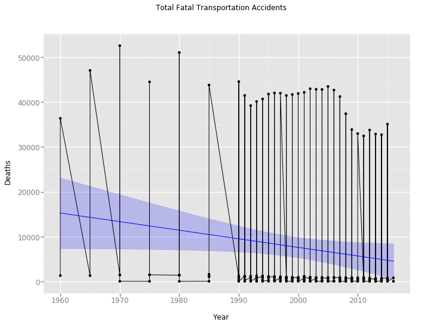

```python
import warnings
warnings.filterwarnings("ignore")

df1 = pd.melt(totals).dropna()
df = totals
df1 = df1.apply(pd.to_numeric)

ggplot(df1, aes(x='variable',y='value')) + \
    geom_point() + geom_line() + stat_smooth(color='blue') +\
    xlab("Year") + ylab("Deaths") +\
    ggtitle('Total Fatal Transportation Accidents')
```

The points on the graph are a bit hard to read since there's such a large difference between the number of highway accidents and all other modes of transportation. So we’ll separate the modes of transport into different graphs next.

So lets split the modes of transport into separate tables to see each trend in more detail.

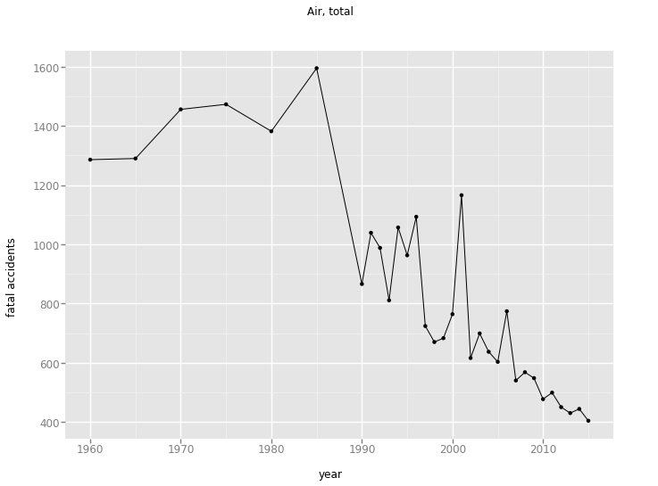

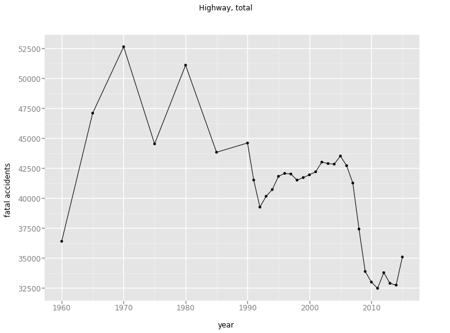

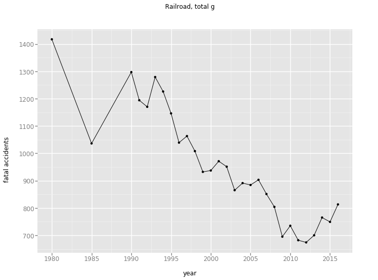

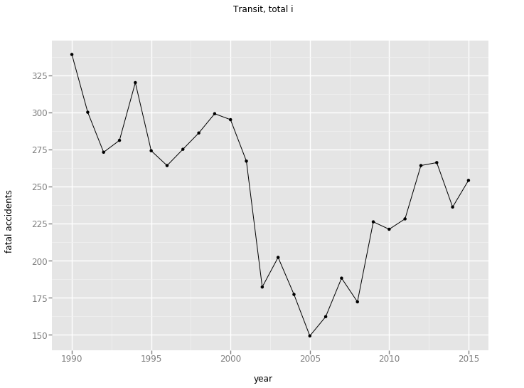

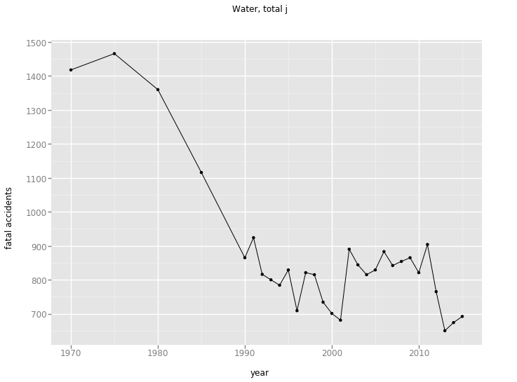

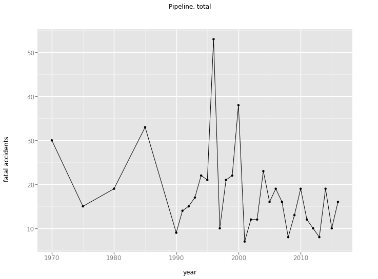

```python
# For each row (mode of transport) in the table
highway_accidents = pd.DataFrame()
for index, row in df.iterrows():
    # make it into a new frame (to be able to plot it)
    x = pd.DataFrame(row)
    # get the title
    title = x.columns.values[0]
    # lets save the highway frame
    if title == 'Highway, total':
        highway_accidents = x.T
    x['year'] = x.index
    x = x.apply(pd.to_numeric)
    x.columns.values[0] = 'fatal accidents'
    # plot it
    g = ggplot(x, aes(x='year',y='fatal accidents')) + \
    geom_point() + geom_line() + ggtitle(title)
    print(g)
```

As expected, the largest number of fatal accidents happens on highways. The most dramatic percentage decrease happened in the air from a peak of 1600 in 1985 to 400 last year. But highway accidents also decreased significantly from about 52K in 1970 to about 35K last year.

The transit graph shows one of the smallest changes with an interesting valley around 2005. And although this is beyond the scope of this tutorial, a possible hypothesis would be that it correlates with the number of people taking public transit which in turn might correlate with GDP growth (I might be wrong and there likely is more then one factor). So I'll leave this for someone else to explore.

[figure not shown]

So lets take a look at the number of fatal accidents. We know they have gone down both overall and for each mode, but to really know by how much we’d have to take into account the number of vehicles on the road. For this, we can look at this table (called vehicles.csv) in the data folder.

https://www.rita.dot.gov/bts/sites/rita.dot.gov.bts/files/publications/national_transportation_statistics/html/table_01_11.html

We can use these numbers to normalize the accidents count for each year. But first lets load the table into a dataframe and clean it up the same way we did above.

```python
vehicles = pd.read_csv('data/vehicles.csv', header=1)
# We can rename column 'Unnamed: 0'
vehicles = vehicles.rename(columns={'Unnamed: 0': 'Type'})
# We can make road into an index
vehicles.index = vehicles['Type']
del vehicles['Type']
# Getting rid of columns and rows (axis) that are all NaN
vehicles = vehicles.dropna(axis=[0,1],how='all')
vehicles = vehicles.replace(['U','N'], np.nan)
vehicles = vehicles.apply(lambda s: s.str.replace('\(R\)', ''))
# make strings of characters into numbers
vehicles = vehicles.apply(lambda s: s.str.replace(',', ''))
vehicles = vehicles.apply(pd.to_numeric, args=('ignore',))
vehicles.head()
```

| Type | 1960 | 1965 | 1970 | 1975 | 1980 | 1985 | 1990 | 1991 | 1992 | 1993 | ... | 2006 | 2007 | 2008 | 2009 | 2010 | 2011 | 2012 | 2013 | 2014 | 2015 |
| --- | --- | --- | --- | --- | --- | --- | --- | --- | --- | --- | --- | --- | --- | --- | --- | --- | --- | --- | --- | --- | --- |
| Air carriera | 2135.0 | 2125.0 | 2679.0 | 2495.0 | 3808.0 | 4678.0 | 6083.0 | 6054.0 | 7320.0 | 7297.0 | ... | 7637.0 | 7732.0 | 7337.0 | 7169.0 | 7185.0 | 7168.0 | 6914.0 | 6740.0 | 6761.0 | 6876.0 |
| General aviationb (active fleet) | 76549.0 | 95442.0 | 131743.0 | 168475.0 | 211045.0 | 210654.0 | 198000.0 | 196874.0 | 185650.0 | 177120.0 | ... | 221943.0 | 231607.0 | 228663.0 | 223877.0 | 223370.0 | 222250.0 | 209034.0 | 199927.0 | 204408.0 | 210030.0 |
| Highway, total (registered vehicles) | 74431800.0 | 91739623.0 | 111242295.0 | 137912779.0 | 161490159.0 | 177133282.0 | 193057376.0 | 192313834.0 | 194427346.0 | 198041338.0 | ... | 250844644.0 | 254403081.0 | 255917664.0 | 254212610.0 | 250070048.0 | 253215681.0 | 253639386.0 | 255876822.0 | 260350938.0 | 263610219.0 |
| Light duty vehicle, short wheel basec | NaN | NaN | NaN | NaN | NaN | NaN | NaN | NaN | NaN | NaN | ... | NaN | 196491176.0 | 196762927.0 | 193979654.0 | 190202782.0 | 183522635.0 | 183171882.0 | 184497490.0 | 187554928.0 | 189618308.0 |
| Passenger carsc | 61671390.0 | 75257588.0 | 89243557.0 | 106705934.0 | 121600843.0 | 127885193.0 | 133700496.0 | 128299601.0 | 126581148.0 | 127327189.0 | ... | 135399945.0 | NaN | NaN | NaN | NaN | NaN | NaN | NaN | NaN | NaN |

5 rows × 32 columns

We notice that Highway vehicles is the only one with total numbers. So lets look at it since the numbers are so much larger then all other modes.

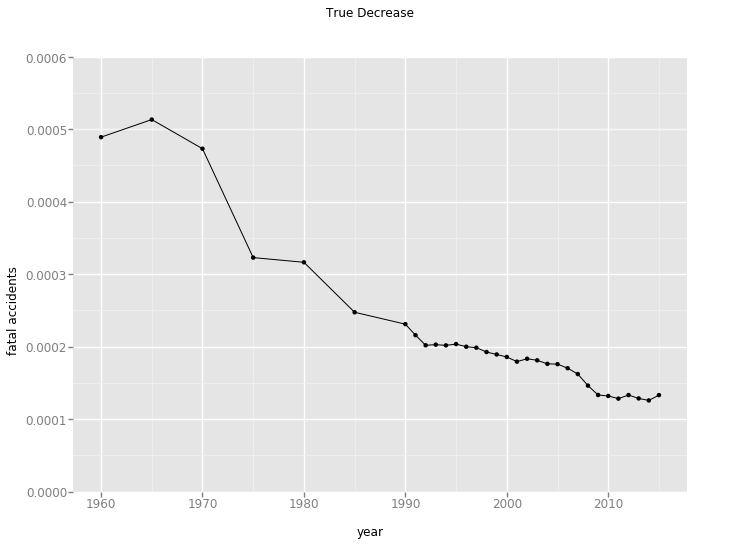

```python
number_of_vehicles = vehicles[vehicles.index == 'Highway, total (registered vehicles)']
normalized = highway_accidents.div(number_of_vehicles.ix[0],axis='columns')
normalized = normalized.T
normalized['year'] = normalized.index
normalized.columns.values[0] = 'fatal accidents'
figsize = (9, 19)
ggplot(normalized, aes(x='year',y='fatal accidents')) + \
    geom_point() + geom_line() + ggtitle('True Decrease') + ylim(0,0.0006)
```

Compared to the Non-Normalized graph we had above:

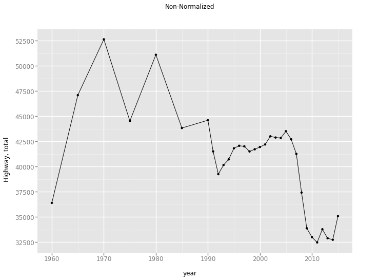

```python
highway_accidents = highway_accidents.T
highway_accidents['year'] = highway_accidents.index
# plot it
ggplot(highway_accidents, aes(x='year',y='Highway, total')) + \
    geom_point() + geom_line() + ggtitle('Non-Normalized')
```

Nice. That’s a much steeper decrease then our Highway, total graph above. There’s also much less volatility which could indicate that the abrupt short term changes are likely caused by changes of the umber of people driving.

So if want to look at the percentage decrease from 1960 to 2015 in the normalized and non-normalized data we see that if we don’t take the number of vehicles on the road into account we only see a 3.6% decrease between 1960 and 2015 but if we do decrease changes to 72.8%:

```python
(1 - int(highway_accidents[highway_accidents.index == '2015']['Highway, total']) /\
int(highway_accidents[highway_accidents.index == '1960']['Highway, total'])) * 100
```

```
3.5907579878568074
```

```python
(1 - float(normalized[normalized.index == '2015']['fatal accidents']) /\
float(normalized[normalized.index == '1960']['fatal accidents'])) * 100
```

```
72.77831850820837
```

# Using Maps To Explore Data

Another way of gaining insights into data is by using maps. We’ll be using Folium do add layers of information to visual maps.

But first we’ll need a different (and bigger) data set that contains location information. One of these tables is the accidents table compiled by the NHTSA. This table has a lot of data. It has so much data you could write a book about it. And someone at the NHTSA has. The file called USERGUIDE.pdf above has information about every column and what they mean.

We can start by once again by getting the csv into a dataframe.

```python
# Load the data into pandas DataFrame
fatalities = pd.read_csv('data/accident.csv')
fatalities.head()
```

|  | STATE | ST_CASE | VE_TOTAL | VE_FORMS | PVH_INVL | PEDS | PERNOTMVIT | PERMVIT | PERSONS | COUNTY | ... | NOT_MIN | ARR_HOUR | ARR_MIN | HOSP_HR | HOSP_MN | CF1 | CF2 | CF3 | FATALS | DRUNK_DR |
| --- | --- | --- | --- | --- | --- | --- | --- | --- | --- | --- | --- | --- | --- | --- | --- | --- | --- | --- | --- | --- | --- |
| 0 | 1 | 10001 | 1 | 1 | 0 | 0 | 0 | 1 | 1 | 73 | ... | 31 | 9 | 36 | 88 | 88 | 0 | 0 | 0 | 1 | 1 |
| 1 | 1 | 10002 | 1 | 1 | 0 | 0 | 0 | 2 | 2 | 73 | ... | 99 | 20 | 5 | 99 | 99 | 0 | 0 | 0 | 1 | 1 |
| 2 | 1 | 10003 | 2 | 1 | 1 | 0 | 1 | 1 | 2 | 73 | ... | 99 | 2 | 31 | 88 | 88 | 0 | 0 | 0 | 1 | 0 |
| 3 | 1 | 10004 | 1 | 1 | 0 | 0 | 0 | 1 | 1 | 73 | ... | 99 | 21 | 57 | 99 | 99 | 0 | 0 | 0 | 1 | 1 |
| 4 | 1 | 10005 | 1 | 1 | 0 | 0 | 0 | 1 | 1 | 73 | ... | 7 | 20 | 10 | 88 | 88 | 0 | 0 | 0 | 1 | 0 |

5 rows × 52 columns

It has a lot of info for each fatal accident:

```python
fatalities.columns.values
```

```
array(['STATE', 'ST_CASE', 'VE_TOTAL', 'VE_FORMS', 'PVH_INVL', 'PEDS',
       'PERNOTMVIT', 'PERMVIT', 'PERSONS', 'COUNTY', 'CITY', 'DAY',
       'MONTH', 'YEAR', 'DAY_WEEK', 'HOUR', 'MINUTE', 'NHS', 'RUR_URB',
       'FUNC_SYS', 'RD_OWNER', 'ROUTE', 'TWAY_ID', 'TWAY_ID2', 'MILEPT',
       'LATITUDE', 'LONGITUD', 'SP_JUR', 'HARM_EV', 'MAN_COLL', 'RELJCT1',
       'RELJCT2', 'TYP_INT', 'WRK_ZONE', 'REL_ROAD', 'LGT_COND',
       'WEATHER1', 'WEATHER2', 'WEATHER', 'SCH_BUS', 'RAIL', 'NOT_HOUR',
       'NOT_MIN', 'ARR_HOUR', 'ARR_MIN', 'HOSP_HR', 'HOSP_MN', 'CF1',
       'CF2', 'CF3', 'FATALS', 'DRUNK_DR'], dtype=object)
```

And has a lot of accidents:

```python
len(fatalities.index)
```

```
34439
```

And that's just for 2016. You can find datasets for every year and more here ftp://ftp.nhtsa.dot.gov/FARS/

So lets start by showing some points on the map to get a general sense of where things happen.

Below we use Folium’s circle maker to add points to the map. Folium has many ways to interact with maps some of which will explore here. But if you wanna see more check out Folium page https://folium.readthedocs.io/en/latest/

```python
# make the map
map_osm = folium.Map(location=[40.45, -99.40], tiles='stamentoner', zoom_start=4)
# we'll just sample 1000 points at random, but feel free to change this
df = fatalities.sample(n=1000)
# just going through every row and adding a circle to the map
for i,row in df.iterrows():
        folium.CircleMarker(location=[row['LATITUDE'], row['LONGITUD']],
                    radius=1,
                    popup='test',
                    color='magenta').add_to(map_osm)
map_osm
```

[interactive chart not shown]

What if we wanted to figure out which day of the week has more accidents. According to the user guide the week starts with Sunday (1) and ends with Saturday (7)

So we can use ggplot's geo_bar() feature to make a bar graph from every the count of each value in the DAY_WEEK coulumn.

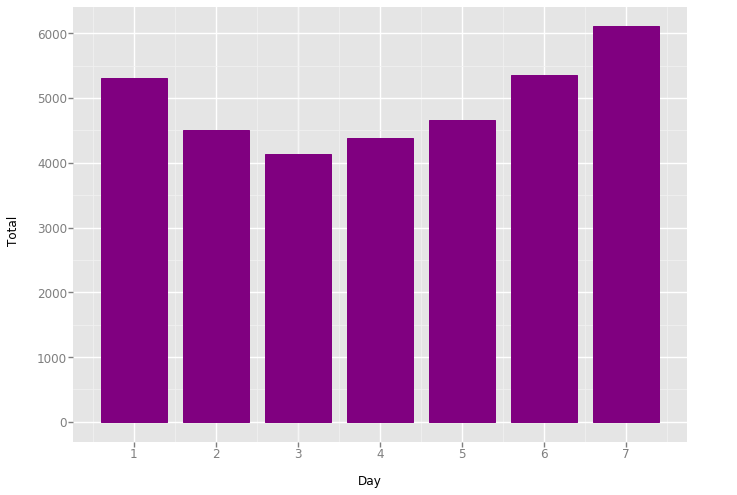

```python
ggplot(aes(x="DAY_WEEK"), fatalities) + geom_bar(fill='purple') + xlab("Day") + ylab("Total")
```

It looks like most fatal accidents happen around the weekend with a peak on Saturday. And all else equal, the safest day to be on the road is Tuesday.

Another thing we could do is try to find out which city harbors most fatal road accidents. To do this, we’ll need to look at both the state and city columns of our dataframe, and group the data by these two attributes. Pandas has an easy way of doing this:

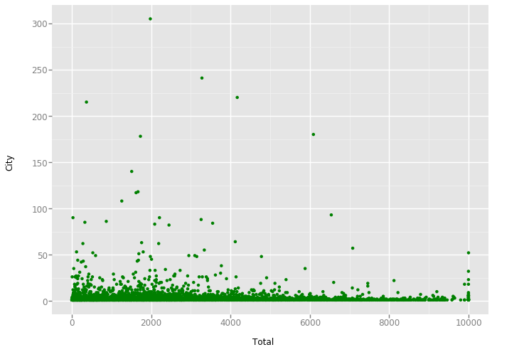

```python
# group by state and city and count how many accidents
df = fatalities[fatalities['CITY'] != 0].groupby(['CITY', 'STATE']).count()
df.reset_index(level=0, inplace=True)
# plot it
ggplot(aes(x="CITY", y="PVH_INVL"), df)  +\
    geom_point(color = 'green') +\
    scale_color_brewer() +\
    xlab("Total") + \
    ylab("City")
```

Alright, lets see what those points at the top are. Since there isn't a way to label points on the graph in ggplot, or at least I haven't found it, I'll just filter out the bottom points with this line

```python
df[df.DAY >= 300].CITY
```

```
STATE
6    1980
Name: CITY, dtype: int64
```

The cities and states are stored by code so I'll to find a way to look up which city has code 1980 and state 6. For this, according to the manual I need to look at what are called GLC codes which I found here https://www.gsa.gov/reference/geographic-locator-codes/glcs-for-the-usa-dc

According to that table the point with over 305 car accident deaths in 2016 is LA, which intuitivly makes sense since the city is large, spread out and has a strong car culture.

We could also take a look at which type of roads most fatal accidents occur on. Again, we'll use the Pandas gorupby function and count the number of distinct occurences in the ROUTE coulomn

```python
fatalities.groupby('ROUTE').count().FATALS
```

```
ROUTE
1     4295
2     5490
3    10234
4     5160
5     1541
6     6104
7      297
8     1138
9      180
Name: FATALS, dtype: int64
```

From the manual, the conversion is this:

```
1 Interstate
2 U.S. Highway
3 State Highway
4 County Road
5 Local Street – Township
6 Local Street – Municipality
7 Local Street – Frontage Road (Since 1994)
8 Other
9 Unknown
```

This seems to show that most car-accident deaths occur on state highways.

Now lets try to do one more thing with Folium before wraping up.

Folium has a HeatMap plugin which can be a nice way of visualizing areas of concentration on the map.

```python
from folium.plugins import HeatMap

m = folium.Map([38.90, -77.036], tiles='stamentoner', zoom_start=10)
data = fatalities.filter(['LATITUDE','LONGITUD'], axis=1)
data = data.values.tolist()
HeatMap(data).add_to(m)

m
```

[interactive chart not shown]

Hm, I didn’t expect that. I did expect to see a larger number of fatal accidents in DC. But Coral Hills and Merrifield were a bit of a surprise. Feel free to change the code do other regions that intrest you.

# Conclusion

Folium and ggplot are a cool way of exploring data in Python. And although we've only scratched the surface, you at least now have a good introduction in using them in combination with Pandas. There are much more libraries out there, some of which might be more useful for what you decide to do. And there is much more data in the NHTSA dataset so don’t feel limited by whats in this data folder.

Hope this was useful.